# Home Work Assignment 6

Pradeep Sahoo

7/14/2018

My Github repository for my assignments can be found at this URL: [My Github](https://github.com/Pradeep-Sahoo/R-Assignments/tree/master/R_Project1)

```r
library(tidyverse)
library(mosaicData)
```

# Exercise 1

```r
data(Whickham)
glimpse(Whickham)
```

```
## Observations: 1,314
## Variables: 3
## $ outcome <fct> Alive, Alive, Dead, Alive, Alive, Alive, Alive, Dead, ...
## $ smoker  <fct> Yes, Yes, Yes, No, No, Yes, Yes, No, No, No, No, Yes, ...
## $ age     <int> 23, 18, 71, 67, 64, 38, 45, 76, 28, 27, 28, 34, 20, 72...
```

What variables are in this data set? There are 3 variables. Outcome, Smoker, Age.

How many observations are there and what does each represent? There are 1,314 observations. Each represents that the person is alive or dead, the person is a smoker or non-smoker and the age of the person

Create a table (use the R code below as a guide) and a visualization of the relationship between smoking status and outcome, ignoring age. What do you see? Does it make sense?

```r
Whickham %>% count( outcome , smoker  )
```

| outcome | smoker | n |
| --- | --- | --- |
| Alive | No | 502 |
| Alive | Yes | 443 |
| Dead | No | 230 |
| Dead | Yes | 139 |

```r
Whickham_mod <- Whickham %>%as_tibble() %>% group_by(outcome , smoker, age) %>% mutate(count = n())
```

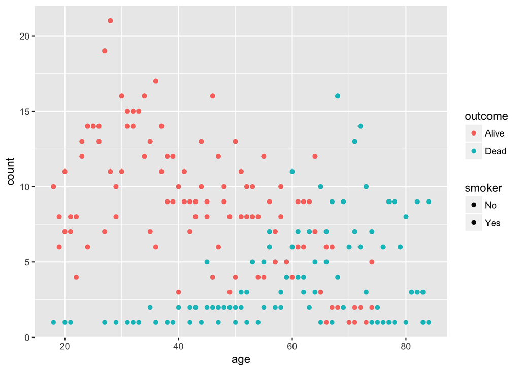

```r
Whickham_mod %>% ggplot() + geom_point(aes(x = age, y = count, fill = smoker, color = outcome))
```

```r
age_cat <- case_when(Whickham$age <= 44 ~ 'Young',
                     Whickham$age > 44 & Whickham$age <= 64 ~ 'Mid',
                     Whickham$age > 64 ~ 'Old')
class(age_cat)
```

```
## [1] "character"
```

```r
age_fct <- factor(age_cat,ordered = TRUE)
levels(age_fct)
```

```
## [1] "Mid"   "Old"   "Young"
```

```r
age_fct_releveled <- fct_relevel(age_fct, 'Young','Mid','Old' )
levels(age_fct_releveled)
```

```
## [1] "Young" "Mid"   "Old"
```

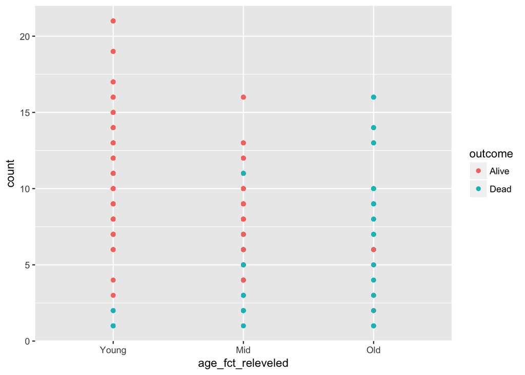

```r
Whickham_mod %>% ggplot() + geom_point(mapping = aes(x = age_fct_releveled, y = count, color = outcome))
```

# Exercise 2

```r
n <- 10000
gamma_samp <- tibble(x = rgamma(n, shape = 1, scale = 2))
```

```r
gamma_samp%>%
summarise(mean = mean(x),sd = sd(x))
```

| mean | sd |
| --- | --- |
| 1.99195 | 1.968475 |

```r
n <- 30
gamma_samp <- (rgamma(n, shape = 1, scale = 2))
m_samp <- mean(gamma_samp)
m_samp
```

```
## [1] 2.328008
```

```r
sd_samp <- sd(gamma_samp)
sd_samp
```

```
## [1] 2.522778
```

```r
gamma_samp <- (x <- rgamma(n, shape = 1, scale = 2))
#gamma_samp %>% ggplot() + geom_histogram(aes(x = x))
```

4. Take a sample of size n = 30, again from the Gamma(1,2) distribution, calculate the mean, and assign it to a vector named mean_samp. Repeat this 10000 times!!!! The code below might help.

```r
# create a vector with 10000 NAs
mean_samp <- rep(NA, 10000)
# start a loop
for(i in 1:10000) {
g_samp <- rgamma(30, shape = 1, scale = 2)
mean_samp[i] <- mean(g_samp)
}
# Convert vector to a tibble
#mean_samp <- tibble(mean_samp)
```

```r
# Need to check with Robert
#g_samp %>% ggplot() + geom_histogram(aes(x = mean_samp))
```

6. Calculate the mean and standard deviation of all of your sample means

```r
mean_of_mean_samp <- mean(mean_samp)
mean_of_mean_samp
```

```
## [1] 2.001113
```

```r
sd_of_mean_samp <- sd(mean_samp)
sd_of_mean_samp
```

```
## [1] 0.3676733
```

7. Did anything surprise you about your answers to #6? result is very close to .365
8. According to the Central Limit Theorem, the mean of your sampling distribution should be very close to 2, and the standard deviation of your sampling distribution should be close to 0.365. Repeat #4-#6, but now with a sample of size n = 300 instead. Do your results match up well with the theorem?

```r
# create a vector with 10000 NAs
mean_samp <- rep(NA, 10000)
# start a loop
for(i in 1:10000) {
g_samp <- rgamma(300, shape = 1, scale = 2)
mean_samp[i] <- mean(g_samp)
}
# Convert vector to a tibble
#mean_samp <- tibble(mean_samp)
```

```r
# Need to check with Robert
#g_samp %>% ggplot() + geom_histogram(aes(x = mean_samp))
```

6. Calculate the mean and standard deviation of all of your sample means

```r
mean_of_mean_samp <- mean(mean_samp)
mean_of_mean_samp
```

```
## [1] 1.999448
```

```r
sd_of_mean_samp <- sd(mean_samp)
sd_of_mean_samp
```

```
## [1] 0.1169972
```

standard deviation of your sampling distribution should be close to should be very close to 0.1154700538. My result is also matching to the expected result.